# Introduction to Bayesian Statistics with R

## \(p\)-value plot recap

Assuming the mean is 0

- compute how extreme the \(t\)-statistic is

\[t = \frac{m - \mu_0}{s_m} = \sqrt{N} \frac{m-\mu_0}{s}\]

Using the Student-\(t\) distribution under the null

\[t_0 \sim \mathcal{T}_{N-1}\]

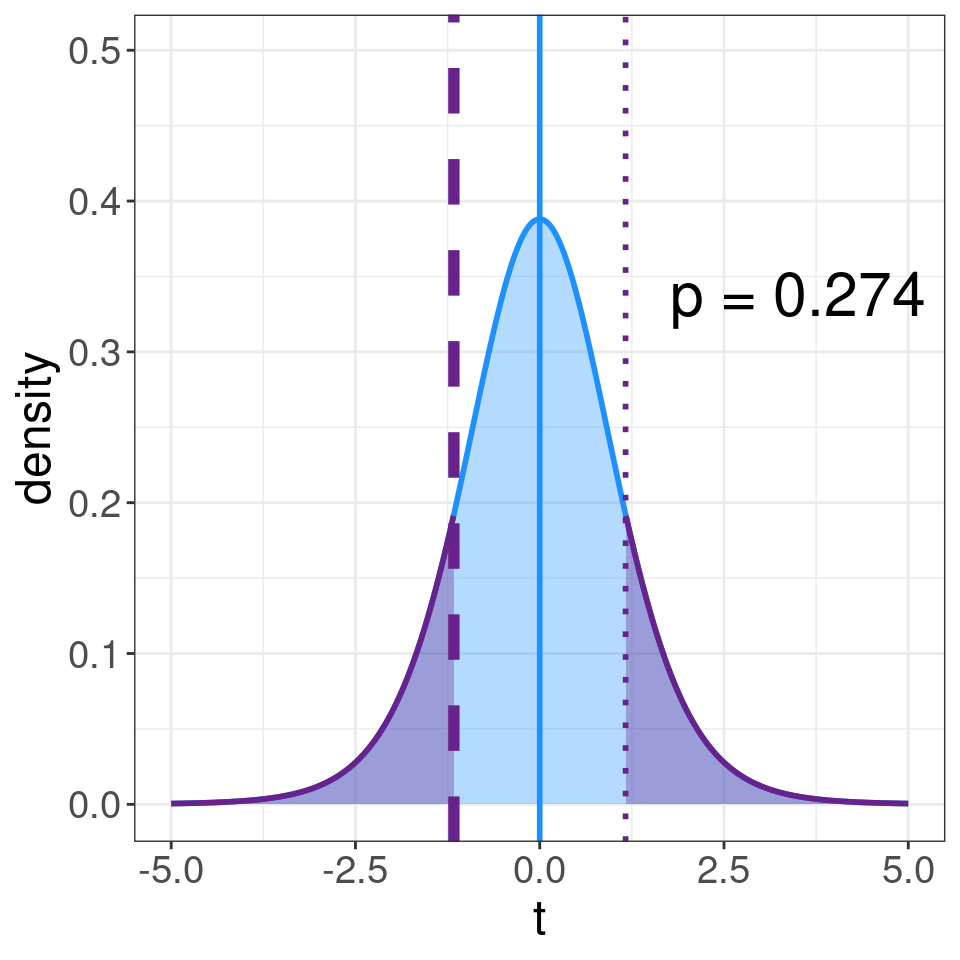

Question: instead of fixing the mean to 0

What is the estimated distribution of the mean itself?

## Confidence intervals

Answer: an “unscaled” student \(t\)

\[m \sim \overline{x} + s_m \mathcal{T}_{N-1} = \overline{x} + \frac{s}{\sqrt{N}} \mathcal{T}_{N-1}\]

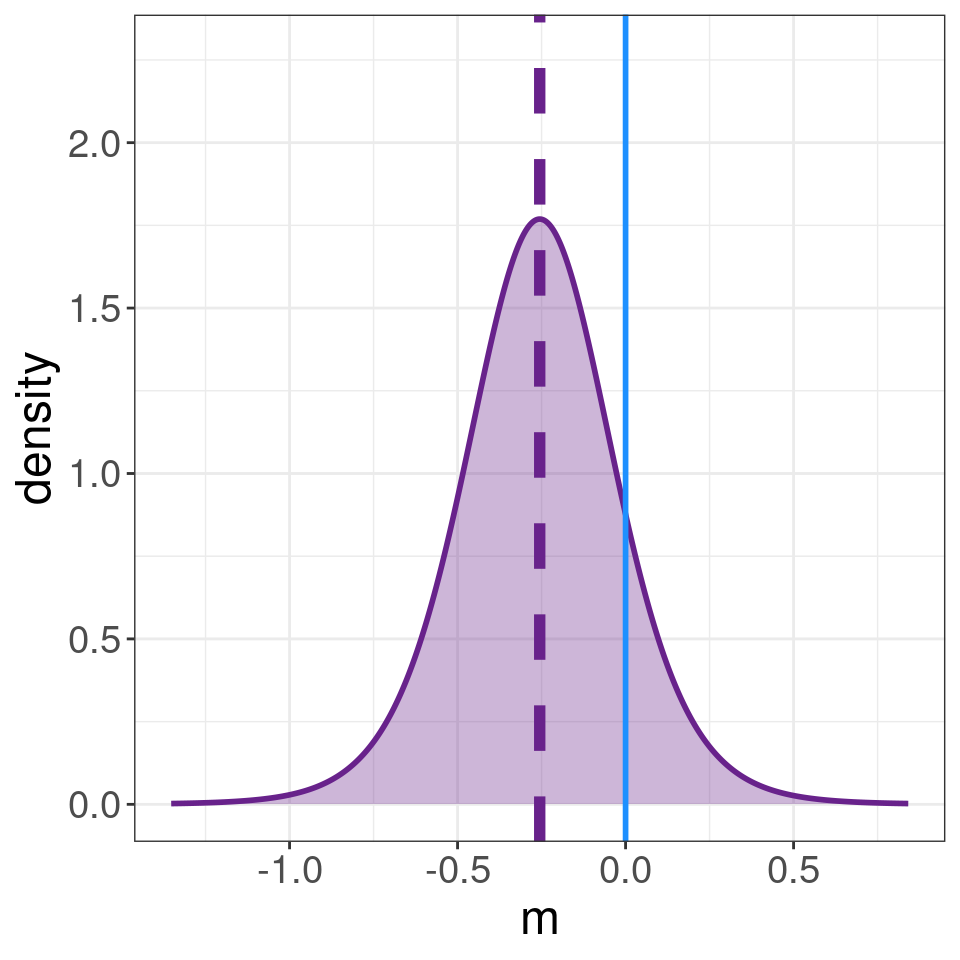

## Confidence intervals

Answer: an “unscaled” student \(t\)

\[m \sim \overline{x} + s_m \mathcal{T}_{N-1} = \overline{x} + \frac{s}{\sqrt{N}} \mathcal{T}_{N-1}\]

The confidence interval contains the central part of the distribution

- usually 95% is chosen

```r
# extract the 95% confidence interval
t.test(test_samples)$conf.int
```

[output not shown]

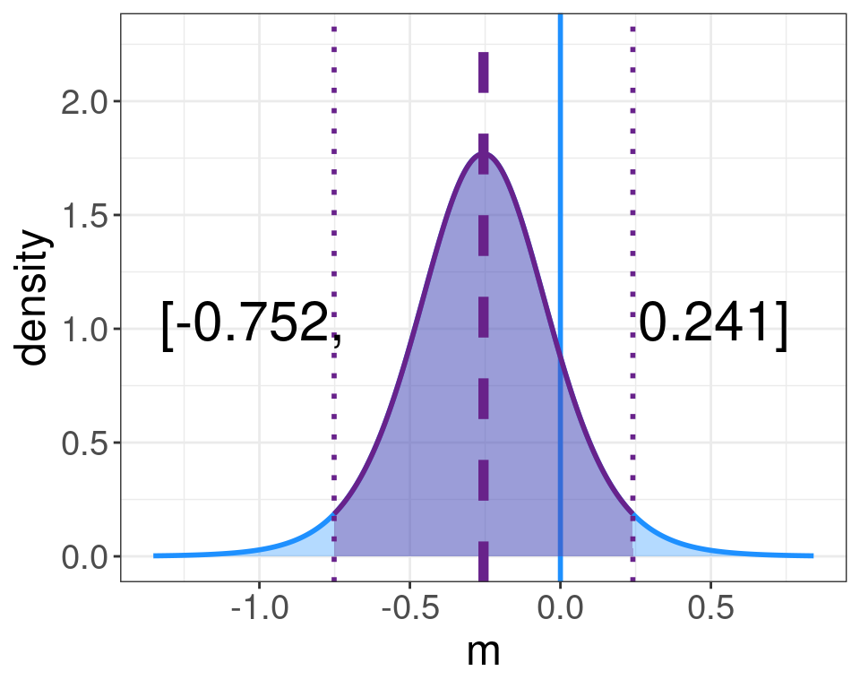

Question: if the 95% confidence interval excludes 0 What can you say about the \(p\)-value?

Answer: it is less than 0.05

## Confidence interval quiz

**Hoekstra et al (2014)**

Professor Bumbledorf conducts an experiment, analyzes the data, and reports:

Please mark each of the following six statements as “true” or “false”. False means that the statement does not follow logically from Bumbledorf’s result. Also note that all, several, or none of the statements may be correct.

\[\left.\right.\]

## Confidence interval quiz

**Hoekstra et al (2014)**

Professor Bumbledorf conducts an experiment, analyzes the data, and reports:

[1.] The probability that the true mean is greater than 0 is at least 95%.

[2.] The probability that the true mean equals 0 is smaller than 5%.

[3.] The “null hypothesis” that the true mean equals 0 is likely to be incorrect.

[4.] There is a 95% probability that the true mean lies between 0.1 and 0.4.

[5.] We can be 95% confident that the true mean lies between 0.1 and 0.4.

[6.] If we were to repeat the experiment over and over, then 95% of the time the true mean falls between 0.1 and 0.4.

Question: which statements are true and which are false?

## Confidence interval quiz

**Hoekstra et al (2014)**

Professor Bumbledorf conducts an experiment, analyzes the data, and reports:

Please mark each of the following six statements as “true” or “false”. False means that the statement does not follow logically from Bumbledorf’s result. Also note that all, several, or none of the statements may be correct.

[1.] The probability that the true mean is greater than 0 is at least 95%.

[2.] The probability that the true mean equals 0 is smaller than 5%.

[3.] The “null hypothesis” that the true mean equals 0 is likely to be incorrect.

[4.] There is a 95% probability that the true mean lies between 0.1 and 0.4.

[5.] We can be 95% confident that the true mean lies between 0.1 and 0.4.

[6.] If we were to repeat the experiment over and over, then 95% of the time the true mean falls between 0.1 and 0.4.

Question: which statements are true and which are false?

## Confidence interval quiz

**Hoekstra et al (2014)**

Professor Bumbledorf conducts an experiment, analyzes the data, and reports:

Please mark each of the following six statements as “true” or “false”. False means that the statement does not follow logically from Bumbledorf’s result. Also note that all, several, or none of the statements may be correct.

[1.] The probability that the true mean is greater than 0 is at least 95%. False

[2.] The probability that the true mean equals 0 is smaller than 5%. False

[3.] The “null hypothesis” that the true mean equals 0 is likely to be incorrect. False

[4.] There is a 95% probability that the true mean lies between 0.1 and 0.4. False

[5.] We can be 95% confident that the true mean lies between 0.1 and 0.4. False

[6.] If we were to repeat the experiment over and over, then 95% of the time the true mean falls between 0.1 and 0.4. False

Answer: the sample mean (and its distribution) is a random variable.  
It depends on the unknown true mean, but we cannot simply “invert”.

## Confidence intervals and p-values

If the 95% confidence interval excludes 0

```
## [1] "[-0.752, 0.241] does not exclude 0"
```

\(\rightarrow\) \(p\)-value is below 5%

```
## [1] "p = 0.274, not below 5%"
```

But the \(p\)-value is the probability of the data (or more extreme) given the null hypothesis

NOT the probability of the hypothesis given the data

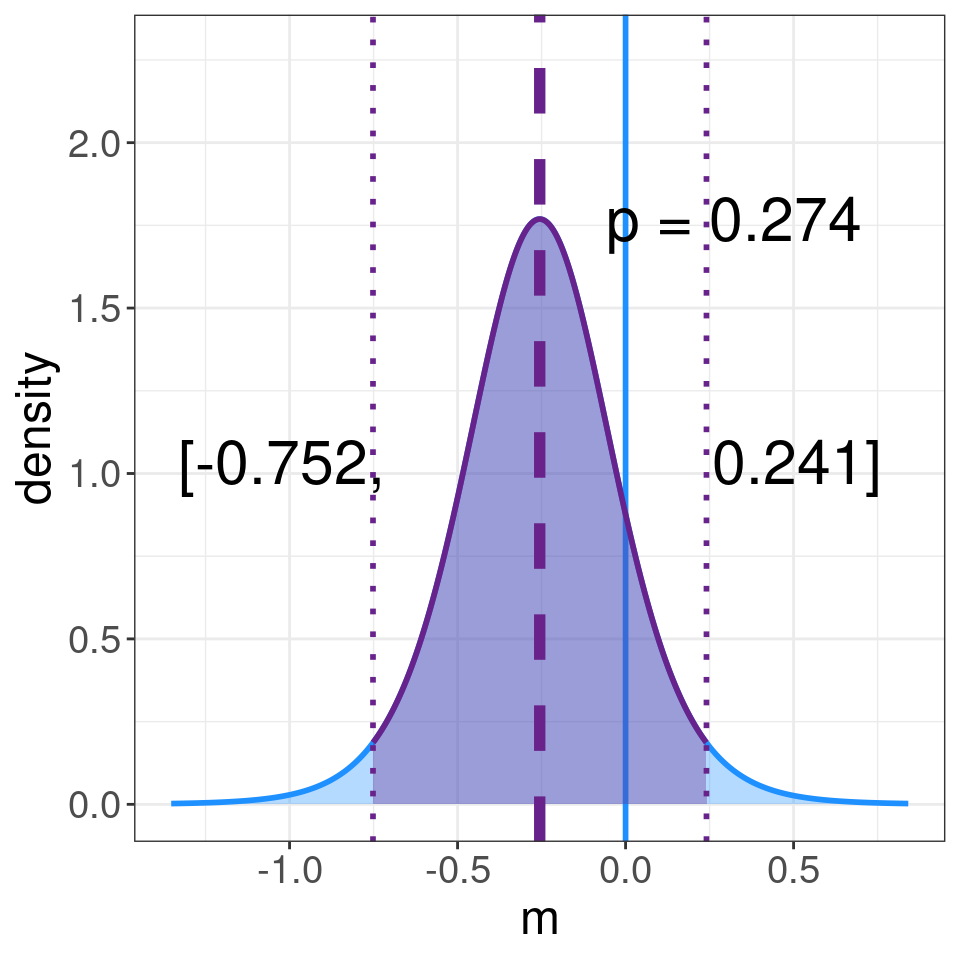

## Probability

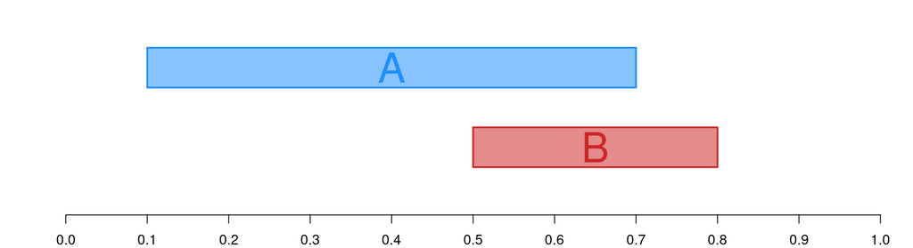

Uniform samples in \((0,1)\) with the runif() function.

Questions: What is \(P(A)\), the probability the sample hits \(A\)? What is \(P(B)\)?

Answers: \(P(A)=\frac{6}{10} = \frac{3}{5}\), \(P(B)=\frac{3}{10}\)

Question: What is \(P(A \cap B)\), the probability the sample hits both \(A\) and \(B\)?

Answer: \(P(A \cap B) = \frac{2}{10} = \frac{1}{5}\)

## Conditional probability

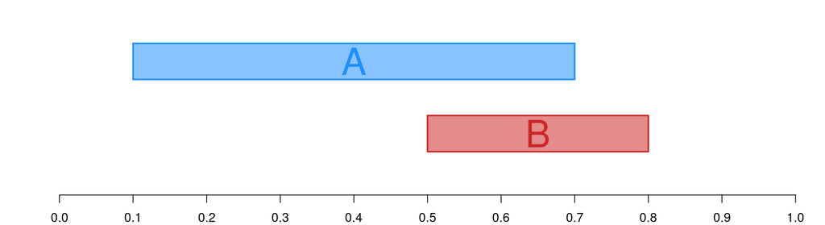

Uniform samples in \((0,1)\) with the runif() function.

Question: what is \(P(B \mid A)\), the probability the sample also hits \(B\), given that it hits \(A\)?

Answer: \(P(B \mid A)=\frac{2}{6} = \frac{1}{3}\)

Question: what is \(P(A \mid B)\)?

Answer: \(P(A \mid B)=\frac{2}{3}\)

## Bayes theorem

Conditional probability

\[ P(B \mid A) = \frac{P(A \cap B)}{P(A)} \]

- we rescale or renormalise to only \(A\) events

Rearrange

\[ P(B \mid A)P(A) = P(A \cap B) = P(A \mid B)P(B) \]

Bayes theorem

\[ P(B \mid A) = \frac{P(A \mid B)P(B)}{P(A)} \, , \qquad P(A) = P(A \mid B)P(B) + P(A \mid \neg B)P(\neg B) \]

Question: All families with two children and at least one daughter are entered into a raffle.

What’s the chance the winning family has two daughters?

Answer: \(\approx\frac{1}{3}\). We renormalise to the three possibilities: \(\{D,D\}\), \(\{D,S\}\), \(\{S,D\}\).

## Family example

What’s the chance the winning family has two daughters? Answer: \(\approx\frac{1}{3}\).

Or we can simulate, or compute:

```r
n_fam <- 1e5 # number of families
first_child <- sample(c("D", "S"),
                n_fam, replace = TRUE)
second_child <- sample(c("D", "S"),
                n_fam, replace = TRUE)
families <- cbind(first_child, second_child)
# remove those with two sons
two_sons <- which(rowSums(families == "S") == 2)
selected_families <- families[-two_sons, ]
# work out the fraction with two daughters
p_two_daughters <- mean(rowSums(
  selected_families == "D") == 2)
# print the simulation results
signif(p_two_daughters, 3)
```

```
## [1] 0.331
```

There are four (approximately) equally likely configurations of the two children

- \(\{D,D\}\), \(\{D,S\}\), \(\{S,D\}\), \(\{S,S\}\).

Denote by \(C\) the condition of at least one daughter

- \(P(C) = \frac{3}{4}\) and \(P(D,D \cap C) = \frac{1}{4}\)

Bayes Theorem:

\[P(D,D \mid C) = \frac{P(D,D \cap C)}{P(C)}\] \[= \frac{\frac{1}{4}}{\frac{3}{4}} = \frac{1}{3}\]

## Bayes theorem and \(p\)-values

The \(p\)-value is the probability of the data (or more extreme) given the null hypothesis

\[p = P(D^{+} \mid H_0)\]

We would like to know the probability of the hypothesis given the data: \(P(H_0 \mid D)\)

\[ P(H_0 \mid D) = \frac{P(D \mid H_0)P(H_0)}{P(D)} \]

- Bayes theorem

Need to know:

- the prior probability of the null hypothesis: \(P(H_0)\)
- \(P(D)\)

\[P(D) = P(D \mid H_0)P(H_0) + P(D \mid \neg H_0)P(\neg H_0)\]

- the likelihood of the data under all other hypotheses: \(P(D \mid \neg H_0)\)

The \(p\)-value does not include this information.

## Summary

\(p\)-values are a measure of surprise

- probability of the data statistic (sample mean) or more extreme given the null

Commonly misinterpreted

- not the probability of the hypothesis given the data!

Confidence intervals are the central part of estimates of the distribution of the statistic (sample mean)

- contain similar information to the \(p\)-value but even more commonly misinterpreted

To “invert” conditional probabilities

- Bayes theorem

\[ P(H_0 \mid D) = \frac{P(D \mid H_0)P(H_0)}{P(D)} \, , \qquad P(D) = P(D \mid H_0)P(H_0) + P(D \mid \neg H_0)P(\neg H_0) \]

Need information beyond the \(p\)-value: the prior \(H_0\) and to consider all alternative hypotheses!

\(\rightarrow\) Exercises 2